# Model Training Workflow

In this notebook we show an example of the Skydipper model training workflow. As an example we train a Convolutional Neural Network for the segmentation of the croplands. As an input we use [Sentinel-2 MSI](https://sentinel.esa.int/web/sentinel/missions/sentinel-2) multispectral data, and as an output crop types data classified by experts from the European Land Use and Coverage Area Frame Survey ([LUCAS](https://ec.europa.eu/eurostat/statistics-explained/index.php/LUCAS_-_Land_use_and_land_cover_survey)) and CropScape – Cropland Data Layer ([CDL](https://nassgeodata.gmu.edu/CropScape/)), respectively.

Datasets in Google Earth Engine:

- [Sentinel-2 MSI: MultiSpectral Instrument, Level-1C](https://developers.google.com/earth-engine/datasets/catalog/COPERNICUS_S2)
- [USDA NASS Cropland Data Layers](https://developers.google.com/earth-engine/datasets/catalog/USDA_NASS_CDL)

## Configure the Environment

We begin by importing a number of useful libraries

```python
import ee
import os
import h5py
import numpy as np
import matplotlib.pyplot as plt
import matplotlib as mpl
```

Initialize the Earth Engine client.

```python
ee.Initialize()
```

## Earth Engine data acquisition

```python
# Central position of (AOIs)
points = [[-120.7224, 37.3872], [-112.6799, 42.9816], [-89.7649, 35.8764],
          [-96.0181, 41.2412], [-115.473, 46.861], [-103.9803, 47.9713],
          [-96.9217, 32.8958], [-82.986, 40.019], [-90.347, 38.668],
          [-110.6947, 37.4568], [-101.8889, 33.5527], [-92.621, 33.417],
          [-80.352, 38.628], [-104.752, 43.972], [-110.92, 37.18]]

# Start and stop of time series
startDate = ee.Date('2016-01-01')
stopDate  = ee.Date('2016-12-31')
# Scale in meters
scale = 10
# Buffer
buffer = 10000
```

```python
from src.lib.preprocess_short.ee_dataset_acquisition import ee_dataset
```

**Define Objects**

```python
sentinel = ee_dataset(points = points, buffer = buffer, startDate = startDate, stopDate = stopDate, scale = scale, file_name='S2_AOI', dataset_name = 'data_x', chunk_size = (128,128), collection = 'Sentinel2')
cropland = ee_dataset(points = points, buffer = buffer, startDate = startDate, stopDate = stopDate, scale = scale, file_name='cropland_AOI', dataset_name = 'data_y', chunk_size = (128,128), collection = 'CroplandDataLayers')
```

**Export `.tif` files to Google Cloud Storage**

```python
sentinel.export_toCloudStorage()
```

```python
cropland.export_toCloudStorage()
```

**Read `.tif` files from Google Cloud Storage**

```python
sentinel.read_fromCloudStorage()
```

```python
cropland.read_fromCloudStorage()
```

**Resize the datasets into small chunks**

```python
sentinel.resize_inChunks()
```

```python
cropland.resize_inChunks()
```

**Merge different AOIs into a single dataset**

```python
sentinel.merge_datasets()
```

```python
cropland.merge_datasets()
```

## Preprocess datasets

```python
from src.lib.preprocess_short.preprocess_datasets import preprocess_datasets
```

**Get normalization values**

```python
preprocess = preprocess_datasets(dataset_names=['data_x','data_y'], collections=['Sentinel2', 'CroplandDataLayers'])
```

```python
preprocess.normalization_values()
```

**Change class labels**

Each class is encoded as a value in the range between 0 to 254. For training a Neural Network in Keras we have to convert the 1-dimensional class arrays to N classes-dimensional matrices. To simplify the problem here we regroup all the classes into 4 categories, namely, land, water, urban, and cropland areas.

```python
preprocess.change_class_labels()
```

**Randomize the datasets**

```python
preprocess.randomize_datasets()
```

**Training and validation sets**

```python
preprocess.train_validation_split(val_size=20)
```

## Train the Network

To train SegNet from the command line type:

```
python train.py -i samples/ -o networks/ -c 4 -e 20 -m segnet -a start
```

The parameters are:

```
-i = samples/
    Path of the input files.
-o = networks/
    Path of the output files that will contain the network weights.
-e = 20
    Number of epochs to use during training.
-m = segnet
    Model name.
-a = {start, continue}
     `start`: start a new calculation
     `continue`: continue a previous calculation
```

## Predict

**Read data**

```python
# Central position of (AOIs)
point = [[-112.0087, 43.4952]]
# Start and stop of time series
startDate = ee.Date('2016-01-01')
stopDate  = ee.Date('2016-12-31')
# Scale in meters
scale = 10
# Buffer
buffer = 10000
```

**Define Objects**

```python
sentinel_predict = ee_dataset(points = point, buffer = buffer, startDate = startDate, stopDate = stopDate, scale = scale, file_name='S2_AOI_pre', dataset_name = 'data_x', chunk_size = (128,128), collection = 'Sentinel2')
cropland_predict = ee_dataset(points = point, buffer = buffer, startDate = startDate, stopDate = stopDate, scale = scale, file_name='cropland_AOI_pre', dataset_name = 'data_y', chunk_size = (128,128), collection = 'CroplandDataLayers')
```

**Export `.tif` files to Google Cloud Storage**

```python
sentinel_predict.export_toCloudStorage()
```

```python
cropland_predict.export_toCloudStorage()
```

**Read `.tif` files from Google Cloud Storage**

```python
sentinel_predict.read_fromCloudStorage()
```

```python
cropland_predict.read_fromCloudStorage()
```

**Change input file names**

```python
def change_file(path, in_name, out_name):
    with h5py.File(path + in_name + ".hdf5", 'r') as f:
        data = f.get(in_name)[:]

        with h5py.File(path + out_name + ".hdf5", 'w') as f:
            data_new = f.create_dataset(out_name, tuple([1]+list(data.shape)), dtype=np.uint8)

            data_new[0,:,:,:] = data[:]

    ## Remove input files
    os.remove(path + in_name + ".hdf5")
```

```python
change_file('./samples/', 'data_x_00', 'data_x')
change_file('./samples/', 'data_y_00', 'data_y')
```

**Change class labels**

```python
preprocess = preprocess_datasets(dataset_names=['data_x','data_y'], collections=['Sentinel2', 'CroplandDataLayers'])
```

```python
preprocess.change_class_labels()
```

**Prediction**

To use SegNet from the command line type:

```
python predict.py -i samples/ -o output/output.hdf5 -c 4 -m segnet
```

The parameters are:

```
-i = samples/
    Path of the input file.
-o = output/output.hdf5
    Path of the output file.
-c = 4
    Number of classes.
-m = segnet
    Model name.
```

## Display results

```python
def display_channels(data, nChannels, titles = False):
    if nChannels == 1:
        plt.figure(figsize=(5,5))
        plt.imshow(data[:,:,0])
        if titles:
            plt.title(titles[0])
    else:
        fig, axs = plt.subplots(nrows=1, ncols=nChannels, figsize=(5*nChannels,5))
        for i in range(nChannels):
            ax = axs[i]
            ax.imshow(data[:,:,i])
            if titles:
                ax.set_title(titles[i])
```

**Read dataset**

```python
f = h5py.File("./samples/data_x.hdf5", 'r')
data_x = f.get("data_x")[:]
f.close()
```

```python
f = h5py.File("./samples/data_y.hdf5", 'r')
data_y = f.get("data_y")[:]
f.close()
```

```python
f = h5py.File("./output/output.hdf5", 'r')
output = f.get("output")[:]
f.close()
```

Sentinel 2 composite (input channels)

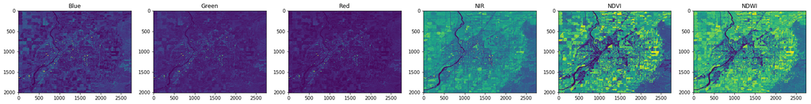

```python
display_channels(data_x[0,:,:,:], data_x.shape[3], titles=['Blue', 'Green', 'Red', 'NIR', 'NDVI', 'NDWI'])
```

Ground truth land cover classification (output channels)

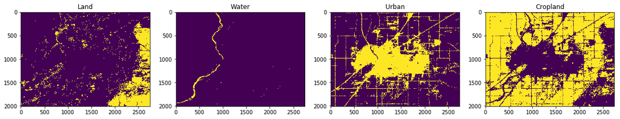

```python
display_channels(data_y[0,:,:,:], data_y.shape[3], titles=['Land', 'Water', 'Urban', 'Cropland'])
```

Network output

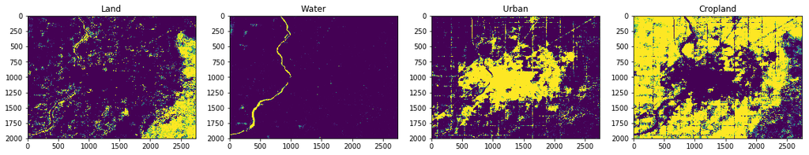

```python
display_channels(output[0,:,:,:], data_y.shape[3], titles=['Land', 'Water', 'Urban', 'Cropland'])
```

We binarize the output taking the highest pixel value

```python
# Binarize the output
def max_pixels(x):
    x_new = x*0
    max_val = np.amax(x, axis=2)
    size = x.shape
    for i in range(size[-1]):
        ima = x[:,:,i]*0
        ima[np.where(x[:,:,i] == max_val)] = 1
        x_new[:,:,i]= ima

    return x_new
```

```python
output_classification = max_pixels(output[0,:,:,:])
```

Predicted land cover classification

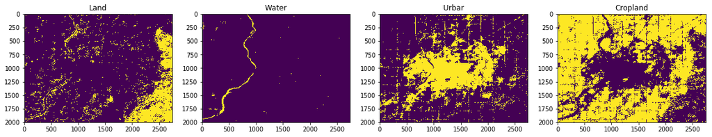

```python
display_channels(output_classification[:,:,:], output.shape[3], titles=['Land', 'Water', 'Urbar', 'Cropland'])
```

## Display Segmentation

```python
def channelnorm(im, channels, vmin, vmax):
    for channel in channels:
        c = (im[:,:,channel]-vmin) / (vmax-vmin)
        c[c<0.] = 0
        c[c>1.] = 1
        im[:,:,channel] = c
    return im
```

```python
# Predicted image
output_segnet = np.copy(output_classification)
output_segnet = np.argmax(output_segnet, axis=2)
dim = output_segnet.shape

# Input image
input_img = np.copy(data_x[0,:dim[0],:dim[1],:3])
input_img = input_img/255.

# Ground truth image
output_truth = np.copy(data_y[0,:dim[0],:dim[1],:])
output_truth = np.argmax(output_truth, axis=2)
```

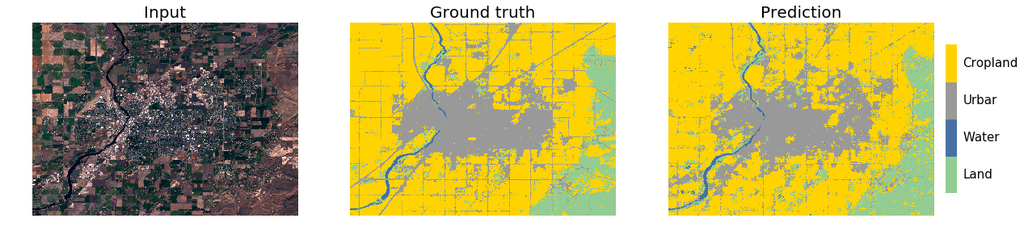

```python
fig, (ax1, ax2, ax3) = plt.subplots(ncols=3, figsize=(20,10))

cmap = mpl.colors.ListedColormap(['#93cc93','#4970a3','#999999','#ffd300'])

vmin = 0.1
vmax = 0.4
channels = [0,1,2]
input_img_sat  = channelnorm(np.copy(input_img), channels, vmin, vmax)

ax1.imshow(input_img_sat)
ax1.set_title('Input', fontsize=20)
ax1.axis('off')

ax2.imshow(output_truth, cmap=cmap)
ax2.set_title('Ground truth', fontsize=20)
ax2.axis('off')

ax3.imshow(output_segnet, cmap=cmap)
ax3.set_title('Prediction', fontsize=20)
ax3.axis('off')

#Plot color bar
plt.imshow(output_segnet, cmap=cmap)
box = ax3.get_position()
cbaxes = plt.axes([box.x0 + box.width + 0.01, box.y0 + 0.25, 0.01, box.height - 0.5])
cb = plt.colorbar(cax=cbaxes, orientation="vertical")
cb.ax.axis('off')
cb.outline.set_visible(False)

for j, lab in enumerate(['Land', 'Water', 'Urbar', 'Cropland']):
    cb.ax.text(1.5, (2 * j + 1) / 8.0, lab, ha='left', va='center', fontsize=15)

plt.savefig('./img/image.pdf', bbox_inches='tight')
```

## Evaluating image segmentation model

### Intersection over Union

The Intersection over Union (IoU) metric, also referred to as the Jaccard index, is essentially a method to quantify the percent overlap between the target mask and our prediction output.

The IoU metric measures the number of pixels common between the target and prediction masks divided by the total number of pixels present across both masks.

$$IoU = \frac{target \cap prediction}{target \cup prediction}$$

The `intersection` ($target \cap prediction$) is comprised of the pixels found in both the prediction mask and the ground truth mask, whereas the `union` ($target \cup prediction$) is simply comprised of all pixels found in either the prediction or target mask.

We can calculate this using Numpy:

```python
output_segnet_class = np.copy(output_classification)
dim = output_segnet_class.shape
output_truth_class = np.copy(data_y[0,:dim[0],:dim[1],:])

IoU_metric = []
for i, category in enumerate(['Land', 'Water', 'Urbar', 'Cropland']):
    intersection = np.logical_and(output_truth_class[:,:,i], output_segnet_class[:,:,i])
    union = np.logical_or(output_truth_class[:,:,i], output_segnet_class[:,:,i])
    iou_score = np.sum(intersection) / np.sum(union)

    IoU_metric.append(iou_score)
    print(category, 'IoU:', "{0:.0f}".format(iou_score*100), '%')
```

```
Land IoU: 47 %
Water IoU: 60 %
Urbar IoU: 60 %
Cropland IoU: 75 %
```

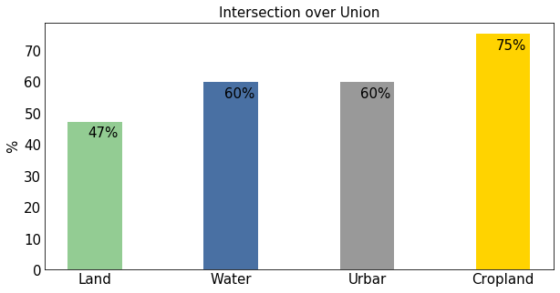

```python
# Data
values = np.array(IoU_metric)*100
locations = ['Land', 'Water', 'Urbar', 'Cropland']    # the x locations for the groups
colors = ['#93cc93','#4970a3','#999999','#ffd300']

# Plot
#plt.figure(figsize=(10,5))

fig, ax = plt.subplots(figsize=(10,5))

ax.bar(locations, values, width=0.40, color=colors)

ax.set_title('Intersection over Union', fontsize=15)
ax.set_ylabel('%', fontsize=15)
ax.tick_params(axis='both', which='both', length=0)
plt.xticks(fontsize=15)
plt.yticks(size=15)

for i, v in enumerate(values):
    ax.text(i-0.05, v-5, "{0:.0f}".format(v) + '%', fontsize=15)

plt.savefig('./img/IoU_score.pdf', bbox_inches='tight')
```